# Seattle Fire Department Calls and Response

```python
import numpy as np
import pandas as pd
import geopandas as gpd
import plotly.express as px
import datetime as dt
import colorcet as ccet
import matplotlib.pyplot as plt
```

```python
df = pd.read_csv('../data/Call_Data.csv', parse_dates=['Original Time Queued','Arrived Time'])
df['Hour Of Day Queued'] = [x.hour for x in df['Original Time Queued']]

df.head()
```

|  | CAD Event Number | Event Clearance Description | Call Type | Priority | Initial Call Type | Final Call Type | Original Time Queued | Arrived Time | Precinct | Sector | Beat | Hour Of Day Queued |
| --- | --- | --- | --- | --- | --- | --- | --- | --- | --- | --- | --- | --- |
| 0 | 2022000018060 | ASSISTANCE RENDERED | 911 | 1 | SFD - ASSIST ON FIRE OR MEDIC RESPONSE | --ASSIST OTHER AGENCY - CITY AGENCY | 2022-01-22 13:35:02 | 2022-01-22 13:49:15 | WEST | QUEEN | Q1 | 13 |
| 1 | 2022000012185 | ASSISTANCE RENDERED | 911 | 1 | SFD - ASSIST ON FIRE OR MEDIC RESPONSE | --ASSIST PUBLIC - OTHER (NON-SPECIFIED) | 2022-01-15 15:42:31 | 2022-01-15 15:49:33 | WEST | DAVID | D3 | 15 |
| 2 | 2022000270039 | REPORT WRITTEN (NO ARREST) | 911 | 1 | SFD - ASSIST ON FIRE OR MEDIC RESPONSE | --SUSPICIOUS CIRCUM. - SUSPICIOUS PERSON | 2022-10-08 12:02:20 | 2022-10-08 12:09:22 | WEST | DAVID | D3 | 12 |
| 3 | 2022000270129 | ASSISTANCE RENDERED | 911 | 1 | SFD - ASSIST ON FIRE OR MEDIC RESPONSE | --ASSIST OTHER AGENCY - CITY AGENCY | 2022-10-08 13:52:28 | 2022-10-08 13:55:53 | NORTH | JOHN | J1 | 13 |
| 4 | 2022000012668 | ASSISTANCE RENDERED | 911 | 1 | SFD - ASSIST ON FIRE OR MEDIC RESPONSE | --ASSIST OTHER AGENCY - CITY AGENCY | 2022-01-16 05:54:11 | 2022-01-16 06:01:21 | NORTH | JOHN | J3 | 5 |

# What times are busiest?

And does it vary by precinct?

```python
px.histogram(df, x='Hour Of Day Queued', color='Precinct', title='SFD Calls By Time Of Day')
```

# What were response times like throughout the day?

```python
df['Response Time'] = [(df['Arrived Time'][x] - df['Original Time Queued'][x]).seconds for x in range(len(df))]
df.info()
```

```
<class 'pandas.core.frame.DataFrame'>
RangeIndex: 2086 entries, 0 to 2085
Data columns (total 13 columns):
 #   Column                       Non-Null Count  Dtype
---  ------                       --------------  -----
 0   CAD Event Number             2086 non-null   int64
 1   Event Clearance Description  2086 non-null   object
 2   Call Type                    2086 non-null   int64
 3   Priority                     2086 non-null   int64
 4   Initial Call Type            2086 non-null   object
 5   Final Call Type              2086 non-null   object
 6   Original Time Queued         2086 non-null   datetime64[ns]
 7   Arrived Time                 1777 non-null   datetime64[ns]
 8   Precinct                     2086 non-null   object
 9   Sector                       2086 non-null   object
 10  Beat                         2086 non-null   object
 11  Hour Of Day Queued           2086 non-null   int64
 12  Response Time                1777 non-null   float64
dtypes: datetime64[ns](2), float64(1), int64(4), object(6)
memory usage: 212.0+ KB
```

```python
px.histogram(df, x='Response Time', range_x=[0,1200],nbins=1000, labels={'Response Time':'Response Time [seconds]'})
```

```python
px.density_heatmap(df, x='Hour Of Day Queued', y='Response Time', range_y=[0, 1200], nbinsy=500, nbinsx=24)
```

# Map Visualizations

How did the volume of calls and response time vary by beat?

```python
import pyproj
gdf = gpd.read_file('../data/SPD_Beats_WGS84.zip')
gdf = gdf.set_index('beat')
```

## Add column for call count for each beat.

```python
## Count the number of calls.
gdf['Call Count'] = [len(df[df['Beat'] == x]) for x in gdf.index]
gdf['Call Count'][gdf['Call Count'] == 0] = np.nan

## Numner of calls per unit area.
gdf['Calls Per Area'] = gdf['Call Count'] / (gdf['st_area_sh']/1e6)

gdf.head()
```

| beat | objectid | first_prec | sector | st_area_sh | st_length_ | geometry | Call Count | Calls Per Area |
| --- | --- | --- | --- | --- | --- | --- | --- | --- |
| 99 | 1 | None | 99 | 2.087731e+08 | 280794.869698 | MULTIPOLYGON (((-122.38226 47.74885, -122.3771... | NaN | NaN |
| B1 | 2 | N | B | 3.888917e+07 | 30766.975027 | POLYGON ((-122.40540 47.67583, -122.40536 47.6... | 70.0 | 1.799987 |
| B2 | 3 | N | B | 5.514478e+07 | 32647.183464 | POLYGON ((-122.36621 47.67599, -122.36606 47.6... | 43.0 | 0.779766 |
| B3 | 4 | N | B | 5.961233e+07 | 36973.284197 | POLYGON ((-122.33801 47.66869, -122.33639 47.6... | 32.0 | 0.536802 |
| C1 | 5 | E | C | 3.255283e+07 | 37950.240898 | POLYGON ((-122.31279 47.61416, -122.31279 47.6... | 32.0 | 0.983018 |

## Add column for average response time by beat.

```python
gdf['Average Response Time'] = [np.nanmean(df[df['Beat'] == x]['Response Time']) for x in gdf.index]
gdf.head()
```

| beat | objectid | first_prec | sector | st_area_sh | st_length_ | geometry | Call Count | Calls Per Area | Average Response Time |
| --- | --- | --- | --- | --- | --- | --- | --- | --- | --- |
| 99 | 1 | None | 99 | 2.087731e+08 | 280794.869698 | MULTIPOLYGON (((-122.38226 47.74885, -122.3771... | NaN | NaN | NaN |
| B1 | 2 | N | B | 3.888917e+07 | 30766.975027 | POLYGON ((-122.40540 47.67583, -122.40536 47.6... | 70.0 | 1.799987 | 698.530612 |
| B2 | 3 | N | B | 5.514478e+07 | 32647.183464 | POLYGON ((-122.36621 47.67599, -122.36606 47.6... | 43.0 | 0.779766 | 667.450000 |
| B3 | 4 | N | B | 5.961233e+07 | 36973.284197 | POLYGON ((-122.33801 47.66869, -122.33639 47.6... | 32.0 | 0.536802 | 602.666667 |
| C1 | 5 | E | C | 3.255283e+07 | 37950.240898 | POLYGON ((-122.31279 47.61416, -122.31279 47.6... | 32.0 | 0.983018 | 336.103448 |

## Quick Map View

The explore function of Geodataframe can be used to quickly see the geographical features and data values associated with each feature. Mouse over a beat, and a window will popup showing the data for the beat.

Feel free to zoom into see more detailes, especially in the downtown Seattle area.

NOTE: in the gdf.explore() section below, you may see a blank panel with an error message about the notebook not being trusted. I addressed this by doing `jupyter trust seattle_fire_response.ipynb` on the command line in a terminal window.

```python
gdf.explore()
```

Make this Notebook Trusted to load map: File -> Trust Notebook

[interactive chart not shown]

The plot() function of Geodataframe is useful to make quick plots of the data columns.

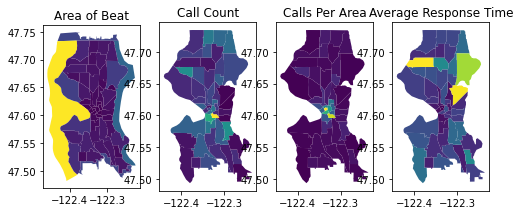

```python
fig = plt.figure(figsize=[8,4])

ax1 = fig.add_subplot(1,4,1)
gdf.plot(column='st_area_sh', ax=ax1)

ax2 = fig.add_subplot(1,4,2)
gdf.plot(column='Call Count', ax=ax2)

ax3 = fig.add_subplot(1,4,3)
gdf.plot(column='Calls Per Area', ax=ax3)

ax4 = fig.add_subplot(1,4,4)
gdf.plot(column='Average Response Time', ax=ax4)

ax1.set_title('Area of Beat')
ax2.set_title('Call Count')
ax3.set_title('Calls Per Area')
ax4.set_title('Average Response Time')
```

## Interactive Maps

Plotly can be used to generate interactive visualizations of the data by beat, using just a few lines of code!

For urban areas, I prefer to use the **choropleth_mapbox()** function. For example, if you zoom in, you can see where the beats's boundaries correspond to specific highways and streets. If you're looking at a larger spatial scale, such as states, countries, or global, consider using a simpler map background using the **choropleth()** function instead.

```python
cols = ccet.rainbow4

fig2 = px.choropleth_mapbox(gdf, width=800, height=800, geojson=gdf.geometry, locations=gdf.index, color='Call Count', opacity=0.5,
                   color_continuous_scale=cols, mapbox_style='open-street-map', center={'lat':47.62,'lon':-122.35}, zoom=10)
fig2.show()
```

```python
cols = ccet.rainbow4

fig3 = px.choropleth_mapbox(gdf, width=800, height=800, geojson=gdf.geometry, locations=gdf.index, color='Calls Per Area', opacity=0.5,
                   color_continuous_scale=cols, mapbox_style='open-street-map', center={'lat':47.62,'lon':-122.35}, zoom=10)
fig3.show()
```

```python
cols = ccet.rainbow4

fig4 = px.choropleth_mapbox(gdf, width=800, height=800, geojson=gdf.geometry, locations=gdf.index, color='Average Response Time', opacity=0.5,
                   color_continuous_scale=cols, mapbox_style='open-street-map', center={'lat':47.62,'lon':-122.35}, zoom=10)
fig4.show()
```